# ASSEMBLY LINE ANALYSIS

#### (Using Bosch Dataset) - Work in progress - THIS IS MY NOTEBOOK MAINTAINED FOR THIS PROJECT AND THE WORK DONE SO FAR IS MENTIONED

### Given Information:

Data represents measurements given in 3 didfferent types of data- numeric, categorical and date and their timestamps on products as they move through production.

At the end quality coontrol accepts or rejects them. The data is anonymized, has many features, is sparse (many many missing values) and is approximately 8gb.

### Initial Exploration

```python
import pandas as pd
import numpy as np
import matplotlib.pyplot as plt

%matplotlib inline
```

```python
ls
```

```
 Volume in drive D is New Volume
 Volume Serial Number is E4BA-7F67

 Directory of D:\Bosch\Datasets

19-12-2016  10:18 AM    <DIR>          .
19-12-2016  10:18 AM    <DIR>          ..
18-12-2016  02:01 AM    <DIR>          .ipynb_checkpoints
13-12-2016  04:01 PM             4,004 .RData
13-12-2016  04:01 PM            10,192 .Rhistory
17-12-2016  02:07 PM            15,783 correlation plot.png
17-12-2016  02:30 PM             7,895 correlation plot2.png
17-12-2016  02:13 PM             1,274 feature correlation.py
17-12-2016  01:10 AM            84,545 flowpaths.png
17-12-2016  10:55 AM           128,429 preliminary analysis1.png
17-12-2016  11:01 AM            10,874 preliminary analysis2.png
17-12-2016  03:30 PM            24,045 prodfams1 - Copy.csv
17-12-2016  01:10 AM            21,196 prodfams1.csv
11-08-2016  05:57 PM        11,281,556 sample_submission.csv
19-10-2016  01:43 PM         1,627,942 sample_submission.csv.zip
11-08-2016  05:57 PM     2,678,272,381 test_categorical.csv
19-10-2016  01:36 PM        20,712,432 test_categorical.csv.zip
19-10-2016  01:46 PM                 0 test_date.csv.zip
11-08-2016  05:43 PM     2,137,286,201 test_numeric.csv
19-10-2016  01:57 PM       283,466,339 test_numeric.csv.zip
11-08-2016  05:50 PM     2,678,343,036 train_categorical.csv
19-10-2016  01:37 PM        20,735,749 train_categorical.csv.zip
11-08-2016  06:12 PM     2,893,367,134 train_date.csv
19-10-2016  01:47 PM        61,622,893 train_date.csv.zip
11-08-2016  05:41 PM     2,139,901,506 train_numeric.csv
19-10-2016  01:56 PM       283,091,778 train_numeric.csv.zip
17-12-2016  03:27 PM             3,988 try.py
19-12-2016  10:18 AM           510,649 Untitled.ipynb
13-12-2016  04:40 PM            11,672 visual.R
13-12-2016  04:34 PM             2,740 visual1.R
              27 File(s) 13,210,546,233 bytes
               3 Dir(s)  119,211,827,200 bytes free
```

```python
sample_submission = pd.read_csv("sample_submission.csv")
sample_submission # ~1.2 million rows (ids of individual products)
```

|  | Id | Response |
| --- | --- | --- |
| 0 | 1 | 0 |
| 1 | 2 | 0 |
| 2 | 3 | 0 |
| 3 | 5 | 0 |
| 4 | 8 | 0 |
| 5 | 10 | 0 |
| 6 | 12 | 0 |
| 7 | 15 | 0 |
| 8 | 17 | 0 |
| 9 | 19 | 0 |
| 10 | 20 | 0 |
| 11 | 21 | 0 |
| 12 | 22 | 0 |
| 13 | 24 | 0 |
| 14 | 25 | 0 |
| 15 | 29 | 0 |
| 16 | 30 | 0 |
| 17 | 32 | 0 |
| 18 | 33 | 0 |
| 19 | 35 | 0 |
| 20 | 36 | 0 |
| 21 | 37 | 0 |
| 22 | 39 | 0 |
| 23 | 40 | 0 |
| 24 | 42 | 0 |
| 25 | 43 | 0 |
| 26 | 45 | 0 |
| 27 | 46 | 0 |
| 28 | 48 | 0 |
| 29 | 50 | 0 |
| ... | ... | ... |
| 1183718 | 2367436 | 0 |
| 1183719 | 2367438 | 0 |
| 1183720 | 2367441 | 0 |
| 1183721 | 2367445 | 0 |
| 1183722 | 2367446 | 0 |
| 1183723 | 2367447 | 0 |
| 1183724 | 2367448 | 0 |
| 1183725 | 2367449 | 0 |
| 1183726 | 2367450 | 0 |
| 1183727 | 2367451 | 0 |
| 1183728 | 2367453 | 0 |
| 1183729 | 2367454 | 0 |
| 1183730 | 2367455 | 0 |
| 1183731 | 2367456 | 0 |
| 1183732 | 2367457 | 0 |
| 1183733 | 2367463 | 0 |
| 1183734 | 2367465 | 0 |
| 1183735 | 2367467 | 0 |
| 1183736 | 2367468 | 0 |
| 1183737 | 2367470 | 0 |
| 1183738 | 2367475 | 0 |
| 1183739 | 2367477 | 0 |
| 1183740 | 2367479 | 0 |
| 1183741 | 2367481 | 0 |
| 1183742 | 2367482 | 0 |
| 1183743 | 2367483 | 0 |
| 1183744 | 2367485 | 0 |
| 1183745 | 2367486 | 0 |
| 1183746 | 2367489 | 0 |
| 1183747 | 2367494 | 0 |

1183748 rows × 2 columns

```python
td = pd.read_csv("train_date.csv", nrows=0)
td
```

|  | Id | L0_S0_D1 | L0_S0_D3 | L0_S0_D5 | L0_S0_D7 | L0_S0_D9 | L0_S0_D11 | L0_S0_D13 | L0_S0_D15 | L0_S0_D17 | ... | L3_S50_D4246 | L3_S50_D4248 | L3_S50_D4250 | L3_S50_D4252 | L3_S50_D4254 | L3_S51_D4255 | L3_S51_D4257 | L3_S51_D4259 | L3_S51_D4261 | L3_S51_D4263 |
| --- | --- | --- | --- | --- | --- | --- | --- | --- | --- | --- | --- | --- | --- | --- | --- | --- | --- | --- | --- | --- | --- |

0 rows × 1157 columns

```python
tn = pd.read_csv("train_numeric.csv", nrows=0)
tn
```

|  | Id | L0_S0_F0 | L0_S0_F2 | L0_S0_F4 | L0_S0_F6 | L0_S0_F8 | L0_S0_F10 | L0_S0_F12 | L0_S0_F14 | L0_S0_F16 | ... | L3_S50_F4245 | L3_S50_F4247 | L3_S50_F4249 | L3_S50_F4251 | L3_S50_F4253 | L3_S51_F4256 | L3_S51_F4258 | L3_S51_F4260 | L3_S51_F4262 | Response |
| --- | --- | --- | --- | --- | --- | --- | --- | --- | --- | --- | --- | --- | --- | --- | --- | --- | --- | --- | --- | --- | --- |

0 rows × 970 columns

```python
tc = pd.read_csv("train_categorical.csv", nrows=0)
tc
```

|  | Id | L0_S1_F25 | L0_S1_F27 | L0_S1_F29 | L0_S1_F31 | L0_S2_F33 | L0_S2_F35 | L0_S2_F37 | L0_S2_F39 | L0_S2_F41 | ... | L3_S49_F4225 | L3_S49_F4227 | L3_S49_F4229 | L3_S49_F4230 | L3_S49_F4232 | L3_S49_F4234 | L3_S49_F4235 | L3_S49_F4237 | L3_S49_F4239 | L3_S49_F4240 |
| --- | --- | --- | --- | --- | --- | --- | --- | --- | --- | --- | --- | --- | --- | --- | --- | --- | --- | --- | --- | --- | --- |

0 rows × 2141 columns

We can infer from this data that the data collected if we ignore the type of the data ie.(F/D) and consider the data to be in the format Lx_Sy_number (where x represents the line number, y represents the station number and number represents the feature number. here we have omitted the D or F respectively eg. L0_S0_F0 is written in the format L0_S0_0) we can infer that all the 4263 features that are measured are distributed across the three different csv file that are partitioned based on the data type and the response whether it passes or fails the test is given

Another question that we have to ask is whether all features are measured for all parts or not In other words we hav to check how imbalanced the classes are or how much of data is missing

```python
train_response = pd.read_csv("train_numeric.csv", usecols=['Response'])
```

We are going to work only on the respomse column to calculate the failure rate

```python
train_response.sum()
```

```
Response    6879
dtype: int64
```

The sum will give us the number of parts that have failed the testing process because the response for the parts that have failed the testing process is 1 and the response for the parts that have passed the quality control is 0

```python
train_response.count()
```

```
Response    1183747
dtype: int64
```

The count value will give us the total number of parts checked

```python
train_response.sum()/train_response.count()
```

```
Response    0.005811
dtype: float64
```

Another possibility that we should consider is that the lines L0, L1 etc might represent different products. The stations are but it is not clear whether it represents the product moving across the line.

```python
train_numeric = pd.read_csv("train_numeric.csv", nrows=1000)
```

The full data is huge and will take an enormous amount of RAM so we are first testing for a smaller chunk of data

Let us first look at the data that failed the quality test

```python
train_numeric[train_numeric['Response'] == 1]
```

|  | Id | L0_S0_F0 | L0_S0_F2 | L0_S0_F4 | L0_S0_F6 | L0_S0_F8 | L0_S0_F10 | L0_S0_F12 | L0_S0_F14 | L0_S0_F16 | ... | L3_S50_F4245 | L3_S50_F4247 | L3_S50_F4249 | L3_S50_F4251 | L3_S50_F4253 | L3_S51_F4256 | L3_S51_F4258 | L3_S51_F4260 | L3_S51_F4262 | Response |
| --- | --- | --- | --- | --- | --- | --- | --- | --- | --- | --- | --- | --- | --- | --- | --- | --- | --- | --- | --- | --- | --- |
| 539 | 1053 | NaN | NaN | NaN | NaN | NaN | NaN | NaN | NaN | NaN | ... | NaN | NaN | NaN | NaN | NaN | NaN | NaN | NaN | NaN | 1 |
| 633 | 1250 | 0.075 | 0.101 | -0.179 | -0.216 | -0.013 | 0.070 | -0.022 | -0.152 | 0.087 | ... | NaN | NaN | NaN | NaN | NaN | NaN | NaN | NaN | NaN | 1 |
| 681 | 1350 | 0.069 | 0.041 | 0.330 | 0.330 | -0.100 | -0.294 | 0.008 | 0.088 | -0.092 | ... | NaN | NaN | NaN | NaN | NaN | NaN | NaN | NaN | NaN | 1 |
| 887 | 1793 | 0.003 | -0.026 | 0.330 | 0.294 | 0.074 | 0.161 | 0.022 | 0.128 | -0.199 | ... | NaN | NaN | NaN | NaN | NaN | NaN | NaN | NaN | NaN | 1 |

4 rows × 970 columns

We can see there there is no specific pattern that can be realised with preliminary analysis. However the number of failed products is very low

```python
train_numeric[train_numeric['L0_S0_F0'].isnull()].filter(regex=("L0_S0_.*"))
```

|  | L0_S0_F0 | L0_S0_F2 | L0_S0_F4 | L0_S0_F6 | L0_S0_F8 | L0_S0_F10 | L0_S0_F12 | L0_S0_F14 | L0_S0_F16 | L0_S0_F18 | L0_S0_F20 | L0_S0_F22 |
| --- | --- | --- | --- | --- | --- | --- | --- | --- | --- | --- | --- | --- |
| 1 | NaN | NaN | NaN | NaN | NaN | NaN | NaN | NaN | NaN | NaN | NaN | NaN |
| 6 | NaN | NaN | NaN | NaN | NaN | NaN | NaN | NaN | NaN | NaN | NaN | NaN |
| 7 | NaN | NaN | NaN | NaN | NaN | NaN | NaN | NaN | NaN | NaN | NaN | NaN |
| 9 | NaN | NaN | NaN | NaN | NaN | NaN | NaN | NaN | NaN | NaN | NaN | NaN |
| 16 | NaN | NaN | NaN | NaN | NaN | NaN | NaN | NaN | NaN | NaN | NaN | NaN |
| 18 | NaN | NaN | NaN | NaN | NaN | NaN | NaN | NaN | NaN | NaN | NaN | NaN |
| 20 | NaN | NaN | NaN | NaN | NaN | NaN | NaN | NaN | NaN | NaN | NaN | NaN |
| 21 | NaN | NaN | NaN | NaN | NaN | NaN | NaN | NaN | NaN | NaN | NaN | NaN |
| 24 | NaN | NaN | NaN | NaN | NaN | NaN | NaN | NaN | NaN | NaN | NaN | NaN |
| 28 | NaN | NaN | NaN | NaN | NaN | NaN | NaN | NaN | NaN | NaN | NaN | NaN |
| 29 | NaN | NaN | NaN | NaN | NaN | NaN | NaN | NaN | NaN | NaN | NaN | NaN |
| 31 | NaN | NaN | NaN | NaN | NaN | NaN | NaN | NaN | NaN | NaN | NaN | NaN |
| 33 | NaN | NaN | NaN | NaN | NaN | NaN | NaN | NaN | NaN | NaN | NaN | NaN |
| 36 | NaN | NaN | NaN | NaN | NaN | NaN | NaN | NaN | NaN | NaN | NaN | NaN |
| 39 | NaN | NaN | NaN | NaN | NaN | NaN | NaN | NaN | NaN | NaN | NaN | NaN |
| 45 | NaN | NaN | NaN | NaN | NaN | NaN | NaN | NaN | NaN | NaN | NaN | NaN |
| 48 | NaN | NaN | NaN | NaN | NaN | NaN | NaN | NaN | NaN | NaN | NaN | NaN |
| 52 | NaN | NaN | NaN | NaN | NaN | NaN | NaN | NaN | NaN | NaN | NaN | NaN |
| 55 | NaN | NaN | NaN | NaN | NaN | NaN | NaN | NaN | NaN | NaN | NaN | NaN |
| 60 | NaN | NaN | NaN | NaN | NaN | NaN | NaN | NaN | NaN | NaN | NaN | NaN |
| 63 | NaN | NaN | NaN | NaN | NaN | NaN | NaN | NaN | NaN | NaN | NaN | NaN |
| 67 | NaN | NaN | NaN | NaN | NaN | NaN | NaN | NaN | NaN | NaN | NaN | NaN |
| 68 | NaN | NaN | NaN | NaN | NaN | NaN | NaN | NaN | NaN | NaN | NaN | NaN |
| 76 | NaN | NaN | NaN | NaN | NaN | NaN | NaN | NaN | NaN | NaN | NaN | NaN |
| 77 | NaN | NaN | NaN | NaN | NaN | NaN | NaN | NaN | NaN | NaN | NaN | NaN |
| 79 | NaN | NaN | NaN | NaN | NaN | NaN | NaN | NaN | NaN | NaN | NaN | NaN |
| 80 | NaN | NaN | NaN | NaN | NaN | NaN | NaN | NaN | NaN | NaN | NaN | NaN |
| 86 | NaN | NaN | NaN | NaN | NaN | NaN | NaN | NaN | NaN | NaN | NaN | NaN |
| 91 | NaN | NaN | NaN | NaN | NaN | NaN | NaN | NaN | NaN | NaN | NaN | NaN |
| 92 | NaN | NaN | NaN | NaN | NaN | NaN | NaN | NaN | NaN | NaN | NaN | NaN |
| ... | ... | ... | ... | ... | ... | ... | ... | ... | ... | ... | ... | ... |
| 933 | NaN | NaN | NaN | NaN | NaN | NaN | NaN | NaN | NaN | NaN | NaN | NaN |
| 939 | NaN | NaN | NaN | NaN | NaN | NaN | NaN | NaN | NaN | NaN | NaN | NaN |
| 942 | NaN | NaN | NaN | NaN | NaN | NaN | NaN | NaN | NaN | NaN | NaN | NaN |
| 944 | NaN | NaN | NaN | NaN | NaN | NaN | NaN | NaN | NaN | NaN | NaN | NaN |
| 946 | NaN | NaN | NaN | NaN | NaN | NaN | NaN | NaN | NaN | NaN | NaN | NaN |
| 947 | NaN | NaN | NaN | NaN | NaN | NaN | NaN | NaN | NaN | NaN | NaN | NaN |
| 948 | NaN | NaN | NaN | NaN | NaN | NaN | NaN | NaN | NaN | NaN | NaN | NaN |
| 951 | NaN | NaN | NaN | NaN | NaN | NaN | NaN | NaN | NaN | NaN | NaN | NaN |
| 956 | NaN | NaN | NaN | NaN | NaN | NaN | NaN | NaN | NaN | NaN | NaN | NaN |
| 957 | NaN | NaN | NaN | NaN | NaN | NaN | NaN | NaN | NaN | NaN | NaN | NaN |
| 959 | NaN | NaN | NaN | NaN | NaN | NaN | NaN | NaN | NaN | NaN | NaN | NaN |
| 962 | NaN | NaN | NaN | NaN | NaN | NaN | NaN | NaN | NaN | NaN | NaN | NaN |
| 963 | NaN | NaN | NaN | NaN | NaN | NaN | NaN | NaN | NaN | NaN | NaN | NaN |
| 964 | NaN | NaN | NaN | NaN | NaN | NaN | NaN | NaN | NaN | NaN | NaN | NaN |
| 970 | NaN | NaN | NaN | NaN | NaN | NaN | NaN | NaN | NaN | NaN | NaN | NaN |
| 972 | NaN | NaN | NaN | NaN | NaN | NaN | NaN | NaN | NaN | NaN | NaN | NaN |
| 973 | NaN | NaN | NaN | NaN | NaN | NaN | NaN | NaN | NaN | NaN | NaN | NaN |
| 976 | NaN | NaN | NaN | NaN | NaN | NaN | NaN | NaN | NaN | NaN | NaN | NaN |
| 978 | NaN | NaN | NaN | NaN | NaN | NaN | NaN | NaN | NaN | NaN | NaN | NaN |
| 982 | NaN | NaN | NaN | NaN | NaN | NaN | NaN | NaN | NaN | NaN | NaN | NaN |
| 983 | NaN | NaN | NaN | NaN | NaN | NaN | NaN | NaN | NaN | NaN | NaN | NaN |
| 984 | NaN | NaN | NaN | NaN | NaN | NaN | NaN | NaN | NaN | NaN | NaN | NaN |
| 985 | NaN | NaN | NaN | NaN | NaN | NaN | NaN | NaN | NaN | NaN | NaN | NaN |
| 986 | NaN | NaN | NaN | NaN | NaN | NaN | NaN | NaN | NaN | NaN | NaN | NaN |
| 987 | NaN | NaN | NaN | NaN | NaN | NaN | NaN | NaN | NaN | NaN | NaN | NaN |
| 992 | NaN | NaN | NaN | NaN | NaN | NaN | NaN | NaN | NaN | NaN | NaN | NaN |
| 993 | NaN | NaN | NaN | NaN | NaN | NaN | NaN | NaN | NaN | NaN | NaN | NaN |
| 994 | NaN | NaN | NaN | NaN | NaN | NaN | NaN | NaN | NaN | NaN | NaN | NaN |
| 995 | NaN | NaN | NaN | NaN | NaN | NaN | NaN | NaN | NaN | NaN | NaN | NaN |
| 996 | NaN | NaN | NaN | NaN | NaN | NaN | NaN | NaN | NaN | NaN | NaN | NaN |

400 rows × 12 columns

Lots of missing data. Let's check that if the first feature in the station is missing will all the features be missing

```python
train_numeric[train_numeric['L0_S0_F0'].isnull()].filter(regex=("L0_S0.*")).sum()
```

```
L0_S0_F0     0.0
L0_S0_F2     0.0
L0_S0_F4     0.0
L0_S0_F6     0.0
L0_S0_F8     0.0
L0_S0_F10    0.0
L0_S0_F12    0.0
L0_S0_F14    0.0
L0_S0_F16    0.0
L0_S0_F18    0.0
L0_S0_F20    0.0
L0_S0_F22    0.0
dtype: float64
```

Looks like it satisfies the condition. Taking more data to be analysed

```python
train_numeric[train_numeric['L0_S0_F0'].isnull()].filter(regex=("L0_.*")).sum()
```

```
L0_S0_F0       0.000
L0_S0_F2       0.000
L0_S0_F4       0.000
L0_S0_F6       0.000
L0_S0_F8       0.000
L0_S0_F10      0.000
L0_S0_F12      0.000
L0_S0_F14      0.000
L0_S0_F16      0.000
L0_S0_F18      0.000
L0_S0_F20      0.000
L0_S0_F22      0.000
L0_S1_F24     -0.225
L0_S1_F28     -0.025
L0_S2_F32      0.000
L0_S2_F36      0.000
L0_S2_F40      0.000
L0_S2_F44      0.000
L0_S2_F48      0.000
L0_S2_F52      0.000
L0_S2_F56      0.000
L0_S2_F60      0.000
L0_S2_F64      0.000
L0_S3_F68      0.009
L0_S3_F72     -0.066
L0_S3_F76     -0.051
L0_S3_F80      0.373
L0_S3_F84     -0.002
L0_S3_F88      0.000
L0_S3_F92      0.019
               ...
L0_S21_F532    0.099
L0_S21_F537   -0.003
L0_S22_F546   -0.513
L0_S22_F551   -0.063
L0_S22_F556   -0.592
L0_S22_F561   -0.451
L0_S22_F566   -1.251
L0_S22_F571   -1.222
L0_S22_F576   -1.062
L0_S22_F581   -0.463
L0_S22_F586   -0.724
L0_S22_F591   -0.862
L0_S22_F596   -0.035
L0_S22_F601   -0.919
L0_S22_F606   -0.477
L0_S22_F611   -0.942
L0_S23_F619    0.177
L0_S23_F623    0.628
L0_S23_F627   -0.025
L0_S23_F631    0.818
L0_S23_F635    1.119
L0_S23_F639    0.924
L0_S23_F643   -0.280
L0_S23_F647   -0.489
L0_S23_F651    0.591
L0_S23_F655    0.407
L0_S23_F659   -0.448
L0_S23_F663   -0.554
L0_S23_F667    1.184
L0_S23_F671   -1.318
dtype: float64
```

#### Not all are NaN if the first feature is NaN

that means a product can be measured somewhere else on the line even if it is not measured on the first station

```python
with pd.option_context('display.max_rows', 9999, 'display.max_columns', 3):
    print(train_numeric.count())
```

```
Id              1000
L0_S0_F0         600
L0_S0_F2         600
L0_S0_F4         600
L0_S0_F6         600
L0_S0_F8         600
L0_S0_F10        600
L0_S0_F12        600
L0_S0_F14        600
L0_S0_F16        600
L0_S0_F18        600
L0_S0_F20        600
L0_S0_F22        600
L0_S1_F24        601
L0_S1_F28        601
L0_S2_F32        311
L0_S2_F36        311
L0_S2_F40        311
L0_S2_F44        311
L0_S2_F48        311
L0_S2_F52        311
L0_S2_F56        311
L0_S2_F60        311
L0_S2_F64        311
L0_S3_F68        290
L0_S3_F72        290
L0_S3_F76        290
L0_S3_F80        290
L0_S3_F84        290
L0_S3_F88        290
L0_S3_F92        290
L0_S3_F96        290
L0_S3_F100       290
L0_S4_F104       303
L0_S4_F109       303
L0_S5_F114       298
L0_S5_F116       298
L0_S6_F118       280
L0_S6_F122       280
L0_S6_F132       280
```

[output cut: 916 more lines]

```
L3_S49_F4231      15
L3_S49_F4236      15
L3_S50_F4241      24
L3_S50_F4243      24
L3_S50_F4245      24
L3_S50_F4247      24
L3_S50_F4249      24
L3_S50_F4251      24
L3_S50_F4253      24
L3_S51_F4256      39
L3_S51_F4258      39
L3_S51_F4260      39
L3_S51_F4262      39
Response        1000
dtype: int64
```

For the most part, if a station has any measurements, all measurements are performed.

- Under this regime, there appears to be some missing data.
- Also, for a few stations, in particular L1_S25, there are irregular numbers of measurements. The values across lines also show that a product can be measured at stations on multiple lines.

Let's examine a few example rows to look for patterns in the stations for which there are measurements.

```python
train_numeric_2 = train_numeric.copy()
train_numeric_2[train_numeric_2['L0_S0_F0'].isnull() == False]
```

|  | Id | L0_S0_F0 | L0_S0_F2 | L0_S0_F4 | L0_S0_F6 | L0_S0_F8 | L0_S0_F10 | L0_S0_F12 | L0_S0_F14 | L0_S0_F16 | ... | L3_S50_F4245 | L3_S50_F4247 | L3_S50_F4249 | L3_S50_F4251 | L3_S50_F4253 | L3_S51_F4256 | L3_S51_F4258 | L3_S51_F4260 | L3_S51_F4262 | Response |
| --- | --- | --- | --- | --- | --- | --- | --- | --- | --- | --- | --- | --- | --- | --- | --- | --- | --- | --- | --- | --- | --- |
| 0 | 4 | 0.030 | -0.034 | -0.197 | -0.179 | 0.118 | 0.116 | -0.015 | -0.032 | 0.020 | ... | NaN | NaN | NaN | NaN | NaN | NaN | NaN | NaN | NaN | 0 |
| 2 | 7 | 0.088 | 0.086 | 0.003 | -0.052 | 0.161 | 0.025 | -0.015 | -0.072 | -0.225 | ... | NaN | NaN | NaN | NaN | NaN | NaN | NaN | NaN | NaN | 0 |
| 3 | 9 | -0.036 | -0.064 | 0.294 | 0.330 | 0.074 | 0.161 | 0.022 | 0.128 | -0.026 | ... | NaN | NaN | NaN | NaN | NaN | NaN | NaN | NaN | NaN | 0 |
| 4 | 11 | -0.055 | -0.086 | 0.294 | 0.330 | 0.118 | 0.025 | 0.030 | 0.168 | -0.169 | ... | NaN | NaN | NaN | NaN | NaN | NaN | NaN | NaN | NaN | 0 |
| 5 | 13 | 0.003 | 0.019 | 0.294 | 0.312 | 0.031 | 0.161 | 0.022 | 0.088 | -0.005 | ... | NaN | NaN | NaN | NaN | NaN | NaN | NaN | NaN | NaN | 0 |
| 8 | 18 | -0.016 | -0.041 | -0.179 | -0.179 | -0.056 | 0.161 | -0.007 | -0.032 | -0.082 | ... | NaN | NaN | NaN | NaN | NaN | NaN | NaN | NaN | NaN | 0 |
| 10 | 26 | 0.016 | 0.093 | -0.015 | -0.016 | 0.031 | 0.116 | -0.007 | -0.072 | 0.209 | ... | NaN | NaN | NaN | NaN | NaN | NaN | NaN | NaN | NaN | 0 |
| 11 | 27 | -0.062 | -0.153 | -0.197 | -0.179 | -0.187 | -0.384 | 0.000 | 0.088 | -0.199 | ... | NaN | NaN | NaN | NaN | NaN | NaN | NaN | NaN | NaN | 0 |
| 12 | 28 | -0.075 | -0.093 | 0.367 | 0.348 | -0.056 | 0.025 | 0.008 | 0.048 | -0.031 | ... | NaN | NaN | NaN | NaN | NaN | NaN | NaN | NaN | NaN | 0 |
| 13 | 31 | -0.003 | -0.093 | -0.161 | -0.216 | 0.118 | -0.021 | -0.015 | 0.048 | -0.031 | ... | NaN | NaN | NaN | NaN | NaN | NaN | NaN | NaN | NaN | 0 |
| 14 | 34 | -0.016 | -0.138 | -0.197 | -0.179 | 0.118 | -0.112 | -0.007 | 0.088 | -0.194 | ... | NaN | NaN | NaN | NaN | NaN | NaN | NaN | NaN | NaN | 0 |
| 15 | 38 | 0.252 | 0.250 | 0.003 | -0.016 | 0.118 | -0.294 | -0.044 | -0.232 | -0.179 | ... | NaN | NaN | NaN | NaN | NaN | NaN | NaN | NaN | NaN | 0 |
| 17 | 44 | -0.016 | -0.041 | 0.003 | -0.016 | -0.143 | -0.339 | 0.000 | 0.048 | 0.081 | ... | NaN | NaN | NaN | NaN | NaN | NaN | NaN | NaN | NaN | 0 |
| 19 | 49 | 0.088 | 0.033 | 0.330 | 0.348 | -0.056 | 0.161 | 0.008 | 0.088 | -0.112 | ... | NaN | NaN | NaN | NaN | NaN | NaN | NaN | NaN | NaN | 0 |
| 22 | 56 | 0.003 | 0.056 | -0.033 | -0.034 | -0.056 | 0.116 | 0.000 | -0.072 | 0.056 | ... | NaN | NaN | NaN | NaN | NaN | NaN | NaN | NaN | NaN | 0 |
| 23 | 57 | 0.010 | -0.034 | -0.197 | -0.197 | 0.118 | 0.025 | -0.015 | -0.032 | 0.112 | ... | NaN | NaN | NaN | NaN | NaN | NaN | NaN | NaN | NaN | 0 |
| 25 | 68 | 0.036 | 0.026 | 0.312 | 0.294 | -0.013 | 0.070 | 0.015 | 0.088 | -0.097 | ... | NaN | NaN | NaN | NaN | NaN | NaN | NaN | NaN | NaN | 0 |
| 26 | 70 | 0.062 | 0.071 | -0.179 | -0.216 | 0.161 | 0.025 | -0.022 | -0.112 | -0.174 | ... | NaN | NaN | NaN | NaN | NaN | 0.0 | 0.0 | 0.0 | 0.0 | 0 |
| 27 | 71 | -0.167 | -0.168 | 0.276 | 0.330 | 0.074 | 0.161 | 0.052 | 0.248 | 0.163 | ... | NaN | NaN | NaN | NaN | NaN | NaN | NaN | NaN | NaN | 0 |
| 30 | 75 | 0.036 | 0.056 | 0.312 | 0.294 | -0.056 | -0.066 | 0.008 | 0.048 | -0.021 | ... | NaN | NaN | NaN | NaN | NaN | NaN | NaN | NaN | NaN | 0 |
| 32 | 78 | 0.101 | 0.108 | 0.003 | -0.052 | 0.074 | -0.021 | -0.022 | -0.072 | 0.010 | ... | NaN | NaN | NaN | NaN | NaN | NaN | NaN | NaN | NaN | 0 |
| 34 | 81 | 0.036 | 0.078 | -0.179 | -0.161 | 0.031 | 0.161 | -0.015 | -0.112 | 0.122 | ... | NaN | NaN | NaN | NaN | NaN | NaN | NaN | NaN | NaN | 0 |
| 35 | 82 | -0.016 | 0.041 | -0.179 | -0.197 | -0.273 | -0.430 | -0.007 | -0.072 | -0.092 | ... | NaN | NaN | NaN | NaN | NaN | NaN | NaN | NaN | NaN | 0 |
| 37 | 86 | -0.003 | 0.041 | -0.033 | -0.016 | 0.074 | 0.161 | 0.000 | -0.072 | 0.025 | ... | NaN | NaN | NaN | NaN | NaN | NaN | NaN | NaN | NaN | 0 |
| 38 | 87 | 0.016 | 0.041 | 0.330 | 0.312 | 0.031 | 0.116 | 0.015 | 0.088 | 0.214 | ... | NaN | NaN | NaN | NaN | NaN | NaN | NaN | NaN | NaN | 0 |
| 40 | 91 | 0.036 | 0.101 | -0.161 | -0.179 | -0.100 | 0.116 | -0.015 | -0.152 | 0.316 | ... | NaN | NaN | NaN | NaN | NaN | NaN | NaN | NaN | NaN | 0 |
| 41 | 92 | 0.108 | 0.093 | -0.052 | -0.034 | 0.031 | 0.116 | -0.022 | -0.072 | -0.067 | ... | NaN | NaN | NaN | NaN | NaN | NaN | NaN | NaN | NaN | 0 |
| 42 | 93 | -0.029 | -0.071 | -0.015 | 0.003 | 0.031 | 0.116 | 0.008 | 0.088 | 0.071 | ... | NaN | NaN | NaN | NaN | NaN | NaN | NaN | NaN | NaN | 0 |
| 43 | 95 | 0.088 | 0.071 | -0.052 | -0.016 | 0.031 | 0.116 | -0.015 | -0.072 | 0.076 | ... | NaN | NaN | NaN | NaN | NaN | NaN | NaN | NaN | NaN | 0 |
| 44 | 96 | 0.010 | 0.056 | -0.015 | -0.016 | 0.031 | 0.161 | -0.007 | -0.072 | 0.168 | ... | NaN | NaN | NaN | NaN | NaN | NaN | NaN | NaN | NaN | 0 |
| ... | ... | ... | ... | ... | ... | ... | ... | ... | ... | ... | ... | ... | ... | ... | ... | ... | ... | ... | ... | ... | ... |
| 943 | 1924 | 0.115 | 0.138 | 0.294 | 0.312 | -0.100 | 0.025 | -0.007 | -0.032 | -0.133 | ... | NaN | NaN | NaN | NaN | NaN | NaN | NaN | NaN | NaN | 0 |
| 945 | 1928 | -0.029 | -0.004 | 0.312 | 0.294 | -0.013 | 0.070 | 0.022 | 0.128 | -0.026 | ... | NaN | NaN | NaN | NaN | NaN | NaN | NaN | NaN | NaN | 0 |
| 949 | 1937 | -0.134 | -0.168 | 0.312 | 0.294 | 0.031 | 0.161 | 0.045 | 0.288 | 0.030 | ... | NaN | NaN | NaN | NaN | NaN | NaN | NaN | NaN | NaN | 0 |
| 950 | 1938 | -0.134 | -0.168 | 0.312 | 0.294 | 0.031 | 0.161 | 0.045 | 0.288 | 0.030 | ... | NaN | NaN | NaN | NaN | NaN | NaN | NaN | NaN | NaN | 0 |
| 952 | 1945 | 0.115 | 0.153 | -0.015 | -0.034 | 0.074 | 0.206 | -0.022 | -0.112 | -0.005 | ... | NaN | NaN | NaN | NaN | NaN | NaN | NaN | NaN | NaN | 0 |
| 953 | 1948 | -0.121 | -0.220 | -0.197 | -0.179 | -0.013 | 0.161 | 0.015 | 0.128 | -0.230 | ... | NaN | NaN | NaN | NaN | NaN | NaN | NaN | NaN | NaN | 0 |
| 954 | 1949 | -0.082 | -0.019 | -0.052 | -0.016 | -0.230 | -0.430 | 0.022 | 0.008 | -0.061 | ... | NaN | NaN | NaN | NaN | NaN | NaN | NaN | NaN | NaN | 0 |
| 955 | 1951 | 0.056 | 0.063 | 0.312 | 0.312 | 0.031 | 0.116 | 0.008 | 0.048 | 0.132 | ... | NaN | NaN | NaN | NaN | NaN | NaN | NaN | NaN | NaN | 0 |
| 958 | 1955 | -0.075 | -0.146 | 0.348 | 0.366 | 0.074 | 0.025 | 0.008 | 0.088 | 0.020 | ... | NaN | NaN | NaN | NaN | NaN | NaN | NaN | NaN | NaN | 0 |
| 960 | 1961 | 0.088 | 0.116 | 0.330 | 0.294 | 0.031 | 0.025 | 0.000 | 0.008 | 0.071 | ... | NaN | NaN | NaN | NaN | NaN | NaN | NaN | NaN | NaN | 0 |
| 961 | 1964 | -0.068 | -0.108 | -0.197 | -0.179 | -0.013 | 0.161 | 0.008 | 0.048 | -0.010 | ... | NaN | NaN | NaN | NaN | NaN | NaN | NaN | NaN | NaN | 0 |
| 965 | 1973 | -0.082 | -0.116 | -0.179 | -0.179 | -0.013 | 0.161 | 0.008 | 0.048 | -0.082 | ... | NaN | NaN | NaN | NaN | NaN | NaN | NaN | NaN | NaN | 0 |
| 966 | 1975 | 0.003 | -0.026 | -0.015 | 0.003 | -0.013 | 0.116 | 0.000 | 0.008 | 0.173 | ... | NaN | NaN | NaN | NaN | NaN | NaN | NaN | NaN | NaN | 0 |
| 967 | 1976 | -0.134 | -0.161 | 0.348 | 0.330 | 0.118 | 0.025 | 0.015 | 0.128 | -0.046 | ... | NaN | NaN | NaN | NaN | NaN | NaN | NaN | NaN | NaN | 0 |
| 968 | 1980 | 0.023 | 0.019 | 0.330 | 0.330 | -0.056 | 0.070 | 0.015 | 0.088 | -0.072 | ... | NaN | NaN | NaN | NaN | NaN | NaN | NaN | NaN | NaN | 0 |
| 969 | 1987 | 0.186 | 0.235 | 0.003 | -0.016 | -0.100 | -0.294 | -0.037 | -0.192 | -0.046 | ... | NaN | NaN | NaN | NaN | NaN | NaN | NaN | NaN | NaN | 0 |
| 971 | 1993 | -0.042 | -0.019 | -0.179 | -0.161 | 0.031 | 0.161 | 0.000 | -0.032 | -0.082 | ... | NaN | NaN | NaN | NaN | NaN | NaN | NaN | NaN | NaN | 0 |
| 974 | 1999 | -0.160 | -0.213 | -0.197 | -0.197 | 0.118 | 0.025 | 0.022 | 0.128 | -0.123 | ... | NaN | NaN | NaN | NaN | NaN | NaN | NaN | NaN | NaN | 0 |
| 975 | 2000 | -0.062 | -0.049 | 0.312 | 0.275 | -0.100 | 0.025 | 0.030 | 0.128 | 0.010 | ... | NaN | NaN | NaN | NaN | NaN | NaN | NaN | NaN | NaN | 0 |
| 977 | 2006 | -0.140 | -0.228 | 0.276 | 0.312 | 0.118 | 0.070 | 0.052 | 0.288 | 0.010 | ... | NaN | NaN | NaN | NaN | NaN | NaN | NaN | NaN | NaN | 0 |
| 979 | 2009 | 0.101 | 0.131 | -0.179 | -0.197 | -0.100 | 0.206 | -0.030 | -0.152 | 0.036 | ... | NaN | NaN | NaN | NaN | NaN | NaN | NaN | NaN | NaN | 0 |
| 980 | 2012 | 0.049 | 0.026 | -0.015 | -0.016 | 0.031 | 0.161 | -0.015 | -0.032 | -0.072 | ... | NaN | NaN | NaN | NaN | NaN | NaN | NaN | NaN | NaN | 0 |
| 981 | 2016 | 0.075 | 0.123 | 0.003 | -0.016 | 0.031 | 0.116 | -0.015 | -0.072 | -0.031 | ... | NaN | NaN | NaN | NaN | NaN | NaN | NaN | NaN | NaN | 0 |
| 988 | 2027 | -0.075 | -0.071 | -0.197 | -0.216 | 0.074 | 0.206 | 0.000 | 0.008 | -0.107 | ... | NaN | NaN | NaN | NaN | NaN | NaN | NaN | NaN | NaN | 0 |
| 989 | 2034 | -0.023 | -0.004 | 0.312 | 0.312 | 0.031 | 0.161 | 0.022 | 0.128 | 0.168 | ... | NaN | NaN | NaN | NaN | NaN | NaN | NaN | NaN | NaN | 0 |
| 990 | 2036 | -0.029 | -0.064 | 0.367 | 0.330 | 0.031 | -0.021 | -0.007 | 0.008 | 0.153 | ... | NaN | NaN | NaN | NaN | NaN | NaN | NaN | NaN | NaN | 0 |
| 991 | 2037 | -0.075 | -0.086 | -0.179 | -0.161 | 0.031 | 0.206 | 0.008 | 0.008 | -0.133 | ... | NaN | NaN | NaN | NaN | NaN | NaN | NaN | NaN | NaN | 0 |
| 997 | 2050 | 0.010 | -0.011 | 0.348 | 0.348 | -0.013 | -0.021 | -0.015 | -0.072 | 0.199 | ... | NaN | NaN | NaN | NaN | NaN | NaN | NaN | NaN | NaN | 0 |
| 998 | 2053 | 0.075 | 0.131 | -0.197 | -0.216 | -0.056 | 0.070 | -0.022 | -0.152 | 0.076 | ... | NaN | NaN | NaN | NaN | NaN | NaN | NaN | NaN | NaN | 0 |
| 999 | 2055 | -0.055 | -0.041 | -0.015 | -0.034 | 0.031 | 0.116 | 0.015 | 0.048 | 0.122 | ... | NaN | NaN | NaN | NaN | NaN | NaN | NaN | NaN | NaN | 0 |

600 rows × 970 columns

```python
train_numeric_2[:5]
```

|  | Id | L0_S0_F0 | L0_S0_F2 | L0_S0_F4 | L0_S0_F6 | L0_S0_F8 | L0_S0_F10 | L0_S0_F12 | L0_S0_F14 | L0_S0_F16 | ... | L3_S50_F4245 | L3_S50_F4247 | L3_S50_F4249 | L3_S50_F4251 | L3_S50_F4253 | L3_S51_F4256 | L3_S51_F4258 | L3_S51_F4260 | L3_S51_F4262 | Response |
| --- | --- | --- | --- | --- | --- | --- | --- | --- | --- | --- | --- | --- | --- | --- | --- | --- | --- | --- | --- | --- | --- |
| 0 | 4 | 0.030 | -0.034 | -0.197 | -0.179 | 0.118 | 0.116 | -0.015 | -0.032 | 0.020 | ... | NaN | NaN | NaN | NaN | NaN | NaN | NaN | NaN | NaN | 0 |
| 1 | 6 | NaN | NaN | NaN | NaN | NaN | NaN | NaN | NaN | NaN | ... | NaN | NaN | NaN | NaN | NaN | NaN | NaN | NaN | NaN | 0 |
| 2 | 7 | 0.088 | 0.086 | 0.003 | -0.052 | 0.161 | 0.025 | -0.015 | -0.072 | -0.225 | ... | NaN | NaN | NaN | NaN | NaN | NaN | NaN | NaN | NaN | 0 |
| 3 | 9 | -0.036 | -0.064 | 0.294 | 0.330 | 0.074 | 0.161 | 0.022 | 0.128 | -0.026 | ... | NaN | NaN | NaN | NaN | NaN | NaN | NaN | NaN | NaN | 0 |
| 4 | 11 | -0.055 | -0.086 | 0.294 | 0.330 | 0.118 | 0.025 | 0.030 | 0.168 | -0.169 | ... | NaN | NaN | NaN | NaN | NaN | NaN | NaN | NaN | NaN | 0 |

5 rows × 970 columns

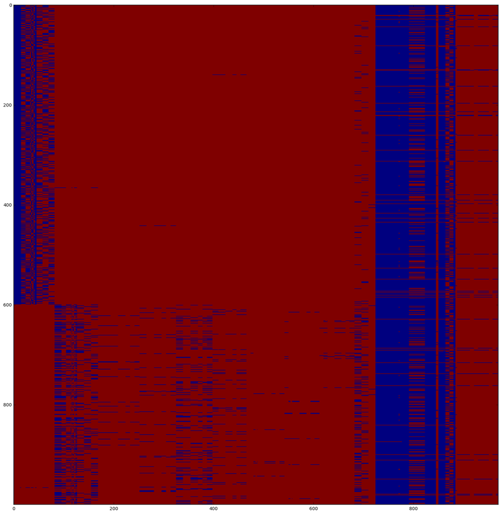

```python
plt.figure(figsize=(20,20))
plt.imshow(train_numeric_2.isnull().sort_values(by=['L0_S0_F0'] ) )
```

There are clearly patterns in the NaN values, but it appears there may be alot of either trully missing values, or a large number of groupings

```python
train_numeric.transpose().count().sort_values().value_counts()
# Number of measurements, number of products measured that many times (Of the first 1000 rows).
```

```
192    332
160    109
212     93
194     90
162     61
206     54
112     26
209     25
164     21
166     20
208     16
222     15
157     14
163     11
195     11
```

[output cut: 39 more lines]

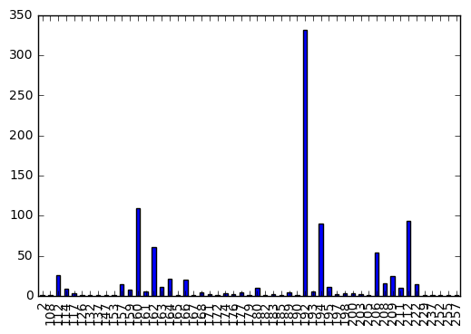

```python
train_numeric.transpose().count().value_counts().sort_index().plot(kind='bar')
```

~80% products in the top 10 # of measurements. Some products are measured a unique number of times. While many products may fit patterns with standard numbers of measurements, it does NOT appear we will quickly and clearly group products by which measurements they are subject to. With this spread, there will be some uncertainty about whether the data is missing or actually represents a different item. It is also possible that instead of missing values, some of the unique entries may represent additional testing performed. This would explain the counts for L1_S25. Whether this is true, or there is missing data, there may be significant differences between the failure rates based upon this value as it would represent some kind of anomoly during production or testing.

Check that the id column matches between all file

We need to determine which columns should be eliminated. We want to eliminate the columns that do not provide more information about the particulat product ie.There are two columns that are almost identical. The best method is feature correlation where we eliminate one of the columns that have a Pearson's correlation value greater than a certain threshold

```
   L0_S0_F0  L0_S0_F2  L0_S0_F4  L0_S0_F6  L0_S0_F8  L0_S0_F10  L0_S0_F12  \
0     0.030    -0.034    -0.197    -0.179     0.118      0.116     -0.015
1       NaN       NaN       NaN       NaN       NaN        NaN        NaN
2     0.088     0.086     0.003    -0.052     0.161      0.025     -0.015
3    -0.036    -0.064     0.294     0.330     0.074      0.161      0.022
4    -0.055    -0.086     0.294     0.330     0.118      0.025      0.030
5     0.003     0.019     0.294     0.312     0.031      0.161      0.022
6       NaN       NaN       NaN       NaN       NaN        NaN        NaN
7       NaN       NaN       NaN       NaN       NaN        NaN        NaN
8    -0.016    -0.041    -0.179    -0.179    -0.056      0.161     -0.007
9       NaN       NaN       NaN       NaN       NaN        NaN        NaN

   L0_S0_F14  L0_S0_F16  L0_S0_F18
0     -0.032      0.020      0.083
1        NaN        NaN        NaN
2     -0.072     -0.225     -0.147
3      0.128     -0.026     -0.046
4      0.168     -0.169     -0.099
5      0.088     -0.005     -0.003
6        NaN        NaN        NaN
7        NaN        NaN        NaN
8     -0.032     -0.082      0.163
9        NaN        NaN        NaN
```

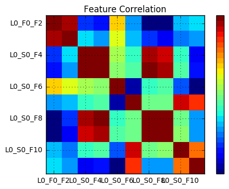

```python
import matplotlib
import numpy as np
import matplotlib.pyplot as plt
import pandas

# Read file into a Pandas dataframe
from pandas import DataFrame, read_csv
df = pandas.read_csv("train_numeric.csv",usecols=[1,2,3,4,5,6,7,8,9,10])
df=df[0:10]
print(df)

#corr = df.corr()
#print(corr)
#fig, ax = plt.subplots(figsize=(10, 10))
#ax.matshow(corr)
#plt.xticks(range(len(corr.columns)), corr.columns);
#plt.yticks(range(len(corr.columns)), corr.columns);
#cbar = fig.colorbar(corr, ticks=[0,.75,.8,.85,.90,.95,1])
#cbar.ax.set_yticklabels(['< -1', '0', '> 1'])

def correlation_matrix(df):
    import numpy as np
    from matplotlib import pyplot as plt
    from matplotlib import cm as cm

    fig = plt.figure()
    ax1 = fig.add_subplot(111)
    cmap = cm.get_cmap('jet', 30)
    cax = ax1.imshow(df.corr(), interpolation="nearest", cmap=cmap)
    ax1.grid(True)
    plt.title('Feature Correlation')
    labels=['L0_S0_F0','L0_F0_F2','L0_S0_F4','L0_S0_F6','L0_S0_F8','L0_S0_F10','L0_S0_F12','L0_S0_F14','L0_S0_F16','L0_S0_F18']
    ax1.set_xticklabels(labels,fontsize=6)
    ax1.set_yticklabels(labels,fontsize=6)

    # Add colorbar, make sure to specify tick locations to6match desired ticklabels
    cbar = fig.colorbar(cax, ticks=[])
    cbar.ax.set_yticklabels(['< -1', '0', '> 1'])
    plt.show()

correlation_matrix(df)
```

```python
train_numeric_id = pd.read_csv("train_numeric.csv", usecols=['Id'])
train_categorical_id = pd.read_csv("train_categorical.csv", usecols=['Id'])
train__date_id = pd.read_csv("train_date.csv", usecols=['Id'])
```

```python
train_numeric_id.equals(train__date_id)
```

```
True
```

```python
train_numeric_id.equals(train_categorical_id)
```

```
True
```

Iterate through the lines of the date csv and produce a dataset with value counts: First, let us examine the features across all files

```python
# Find indicies representing Line and Station for each file.
import pprint

def clean_featurename(feature):
    if '_' in feature:
        feature_tmp = feature.replace('F','')
        feature_tmp = feature_tmp.replace('D','')
        feature_num = feature_tmp.split('_')[-1].zfill(5)
        return feature_num + '_' + feature_tmp
    else:
        return feature

files = ['train_date.csv', 'train_categorical.csv', 'train_numeric.csv']
features = []
for filename in files:
    with open(filename, 'r') as f:
        this_line = [ clean_featurename(feature) + filename for feature in f.readline().split(',')]
        features += this_line
pprint.pprint(sorted(features))
```

```
['00000_L0_S0_0train_numeric.csv',
 '00001_L0_S0_1train_date.csv',
 '00002_L0_S0_2train_numeric.csv',
 '00003_L0_S0_3train_date.csv',
 '00004_L0_S0_4train_numeric.csv',
 '00005_L0_S0_5train_date.csv',
 '00006_L0_S0_6train_numeric.csv',
 '00007_L0_S0_7train_date.csv',
 '00008_L0_S0_8train_numeric.csv',
 '00009_L0_S0_9train_date.csv',
 '00010_L0_S0_10train_numeric.csv',
 '00011_L0_S0_11train_date.csv',
 '00012_L0_S0_12train_numeric.csv',
 '00013_L0_S0_13train_date.csv',
 '00014_L0_S0_14train_numeric.csv',
 '00015_L0_S0_15train_date.csv',
 '00016_L0_S0_16train_numeric.csv',
 '00017_L0_S0_17train_date.csv',
 '00018_L0_S0_18train_numeric.csv',
 '00019_L0_S0_19train_date.csv',
 '00020_L0_S0_20train_numeric.csv',
 '00021_L0_S0_21train_date.csv',
 '00022_L0_S0_22train_numeric.csv',
 '00023_L0_S0_23train_date.csv',
 '00024_L0_S1_24train_numeric.csv',
 '00025_L0_S1_25train_categorical.csv',
 '00026_L0_S1_26train_date.csv',
 '00027_L0_S1_27train_categorical.csv',
 '00028_L0_S1_28train_numeric.csv',
 '00029_L0_S1_29train_categorical.csv',
 '00030_L0_S1_30train_date.csv',
 '00031_L0_S1_31train_categorical.csv',
 '00032_L0_S2_32train_numeric.csv',
 '00033_L0_S2_33train_categorical.csv',
 '00034_L0_S2_34train_date.csv',
 '00035_L0_S2_35train_categorical.csv',
 '00036_L0_S2_36train_numeric.csv',
 '00037_L0_S2_37train_categorical.csv',
 '00038_L0_S2_38train_date.csv',
 '00039_L0_S2_39train_categorical.csv',
```

[output cut: 4213 more lines]

```
 '04254_L3_S50_4254train_date.csv',
 '04255_L3_S51_4255train_date.csv',
 '04256_L3_S51_4256train_numeric.csv',
 '04257_L3_S51_4257train_date.csv',
 '04258_L3_S51_4258train_numeric.csv',
 '04259_L3_S51_4259train_date.csv',
 '04260_L3_S51_4260train_numeric.csv',
 '04261_L3_S51_4261train_date.csv',
 '04262_L3_S51_4262train_numeric.csv',
 '4240\n_L3_S49_4240\ntrain_categorical.csv',
 '4263\n_L3_S51_4263\ntrain_date.csv',
 'Idtrain_categorical.csv',
 'Idtrain_date.csv',
 'Idtrain_numeric.csv',
 'Response\ntrain_numeric.csv']
```

There are some inconsistencies with the timestamps.

The description of the data stated a timestamp represented the feature with the previous feature number. We find multiple features in a row without timestamps. This could mean some measurements are not timestamped, or some measurements occur simultaneously and hence only a single timestamp is needed. We also find some timestamps in a row. I can find no good interpretation of this.

There is no 1:1 relationship between timestamps and the other features. We will start with just the numeric data.

```python
# Get features and gather indecies to sum over for each aggretaion for each file
from collections import defaultdict

def find_feature_group_indices(filename):
    """Summary: Return list of indices for stations and lines in a given file.
    """
    new_features = defaultdict(list)

    with open(filename, 'r') as f:
        first_line = f.readline()
    features = first_line.split(',')
    for index, feature in enumerate(features):
        if '_' in feature:
            line, station, _ = feature.split('_')
            new_features[line].append(index)
            new_features[station].append(index)


    # Replace indices with slice range (it appears they are sequential)
    output_features = defaultdict(tuple)
    for feature, indices in new_features.items():
        # Allow correct sorting
        group_type, group_number = feature[0], feature[1:]
        output_feature = group_type + group_number.zfill(2)

        output_features[output_feature] = (indices[0], indices[-1])

    return output_features
```

```python
from collections import Counter
from multiprocessing import Pool
# We will be processing for each line and for each grouping, so multiprocessing would be useful.

def aggregate_line(line):
    """Summary: Produce aggregation for a single line.
    """
    global feature_indices

    values = line.split(',')
    id = values[0]
    if id == 'Id':
        pass
    else:
        group_aggregate = Counter()
        for group, indices in feature_indices.items():
            # We want the number of features in the group for which we have a measurement.
            group_aggregate[group] = np.sum([value != '' for value in values[ indices[0]:indices[1] ] ])

        return id, group_aggregate

def aggregate_file(filename):
    """Summary: Produce aggregation for a given file.
    """
    pool = Pool(16)
    with open(filename, 'r') as f:
        lines = f.readlines()

    results = pool.map(aggregate_line, lines, 16)

    return results
```

```python
filenames = 'train_numeric.csv'
feature_indices = find_feature_group_indices(filename)
numeric_aggregate = aggregate_file(filename)
```

```python
numeric_aggregate[1]
```

```python
# Output file from the aggregation.
with open('group_aggregate_numeric.csv', 'w') as w:
    w.write('{},{},'.format('Id','Total') + ','.join(sorted(numeric_aggregate[1][1].keys())) + '\n' )
    for id, row in numeric_aggregate[1:]:
        line = sorted([(key, value) for key, value in row.items()])
        values = [str(value) for key, value in line]
        total = np.sum([int(value) for value in values[:3]])
        output = '{},{},'.format(id, total) + ','.join(values)
        w.write('{}\n'.format(output))
```

```python
numeric_group_aggregation = pd.read_csv('group_aggregate_numeric.csv')
```

```python
numeric_group_aggregation
```

[output not shown]

```python
train_response = pd.read_csv("train_numeric.csv", usecols=['Response'])
```

```python
numeric_group_aggregation['Response'] = train_response['Response']
```

```python
numeric_group_aggregation.groupby(['Total'])['Response'].count().plot()
```

[output not shown]

```python
total_groupby = numeric_group_aggregation.groupby(['Total'])

groupbys = pd.DataFrame()
groupbys['mean'] = total_groupby['Response'].mean()
groupbys['count'] = total_groupby['Response'].count()
groupbys['sum'] = total_groupby['Response'].sum()

total_sum = groupbys['sum'].sum()
total_count = groupbys['count'].sum()
```

```python
groupbys
```

[output not shown]

```python
from sklearn.ensemble import RandomForestClassifier
from sklearn.cross_validation import train_test_split

X = numeric_group_aggregation.drop(['Id', 'Response'], axis=1)
y = numeric_group_aggregation['Response']

X_train, X_test, y_train, y_test = train_test_split(X,y)
```

```python
rfc = RandomForestClassifier()
rfc.fit(X_train, y_train)
```

```python
rfc.score(X_test, y_test)
```

[output not shown]

```python
np.mean(rfc.predict(X_test))
```

```python
import xgboost as xgb

dtrain = xgb.DMatrix(X_train, label=y_train)
dtest = xgb.DMatrix(X_test, label=y_test)
```

```python
param = {'bst:max_depth':2, 'bst:eta':.2, 'silent':1, 'objective':'binary:logistic' }
param['nthread'] = 50
param['eval_metric'] = ['auc','error']

evallist  = [(dtest,'eval'), (dtrain,'train')]
```

```python
num_round = 60
bst = xgb.train( param, dtrain, num_round, evallist )
```

```python
pd.Series(bst.get_fscore()).sort_values(ascending=False)
```

```python
from sklearn.metrics import matthews_corrcoef

preds = bst.predict(dtest)
y = dtest.get_label()

def find_best(preds, y):
    best = (0,0)

    for cutoff in np.linspace(0.01, 0.4, num=100):
        mcc = matthews_corrcoef(y, preds>cutoff)
        if mcc > best[1]:
            best = (cutoff, mcc)
        plt.scatter(cutoff, mcc, s=15 )
    plt.show()
    print(best)

find_best(preds, y)
```

[output not shown]

```python
preds
```

```python
preds = [err for acc, err in rfc.predict_proba(X_test)]
find_best(preds, y_test)
```

[output not shown]

- Generate more features:
  - Time lags
  - Outliers count
- Iteratively sample through the original features

Also, a visualization tool for visualizing failures at through each station would be useful.

Work still in progress.